```python
import preprocessing.read as r
import preprocessing.st_ops as ops
import preprocessing.feature_ops as feat
import visualization.builders as vis

import torch
import torch.nn.functional as F
import torch.nn as nn

from torchvision import transforms, utils

from torch_geometric.data import Data
from torch_geometric.data import Batch
from torch_geometric.nn import GCNConv, ChebConv, SAGEConv
from torch_scatter import scatter_mean

import matplotlib
from matplotlib import pyplot as plt
from matplotlib.animation import FuncAnimation

from IPython.display import clear_output, display, HTML

import numpy as np
from numpy import inf

from sklearn.model_selection import KFold
from sklearn.metrics import confusion_matrix
from scipy.spatial.transform import Rotation as R
from scipy import stats

from pythreejs import *

from math import pi

from tqdm import tqdm
import pdb
```

# Introdução

Uma importante área de pesquisa no ramo de aprendizado de máquina, específicamente no tema visão computacional, é o a analise do movimento de uma pessoa. Diversos trabalhos tem sido publicados com diferentes estratégias. Uma estratégia que tem apresentado bons resultados é a análise do movimento observando não diretamente a imagem, mas o esqueleto da pessoa extraído da imagem. O uso de esqueletos, ou grafos, representando a pose humana diversas vantagens sobre a abordagem no domínio das imagens. Esqueletos são robustos à variações de luminosidade, diferentes configurações de cena e preservam o anonimato da pessoa avaliada. Além disso, o corpo humano é naturalmente modelado como um grafo, com juntas e ossos correspondendo aos vértices e arestas, conforme ilustrado na figura abaixo.

[figure not shown]

Apesar do seu grande poder de representação, a utilização de grafos em redes de aprendizado profundo era até bem recentemente um desafio. Por ser uma estrutura muito flexível, não havia forma de fornecer o grafo diretamente como entrada para a rede, sendo necessário um esforço de engenharia de dados antes em busca de representações sobre o qual se poderia basear o aprendizado. Normalmente a engenharia consistia em extrair estatísticas do grafo, seja analisando ele como um todo, seja amostrando pedaços do grafo e construindo estatísticas.

Recentemente, no entanto, as dificuldades foram em grande parte superadas com o desenvolvimento das redes de convolução em grafos (GCN). Uma forma de interpretar as GCNs é vê-las como arquiteturas generalizam a operação de convolução, que atualmente é amplamente utilizada em imagens, para estruturas de dados pouco estruturadas (formalmente, que estão no espaço não-euclidiano), como os grafos. A figura abaixo ilustra a diferença de operações entre o espaço euclidiano e o espaço não-euclidiano.

[figure not shown]

As GCNs extraem informações dos dados utilizando uma abordagem de "transmissão de mensagens", onde cada nó agrega informações de seus vizinhos para gerar representações mais complexas e eventualmente discriminativas. Grafos são dados relacionais sem natureza espacial pré-definida, portanto é necessário definir operações invariantes à ordem dos vértices e tamanho do grafo, generalizando para diferentes conjuntos. [1]

No contexto de análise de movimento, um salto de performance foi alcançado com a aplicação de um modelo espaço temporal que representa as poses de uma pessoa executando um movimento como um grafo. [2]

[1] Kipf, T. N., & Welling, M. (2016). Semi-supervised classification with graph convolutional networks

[2] Yan, S., Xiong, Y., & Lin, D. (2018). Spatial temporal graph convolutional networks for skeleton-based action recognition

[figure not shown]

## Objetivo do trabalho

O objetivo deste trabalho é aplicar uma arquitetura baseada em camadas de convolução em grafos organizados no modelo espaço-temporais para segmentar uma sequência de movimentos de um atleta de taekwondo. Um exemplo do objetivo selecionado pode ser observado na figura abaixo. Ao longo de eixo X temos uma sequência de frames constituida de diversos movimentos de taekwondo. Para cada frame temos uma classificação de qual movimento está sendo realizado. A tarefa consiste em, de posse das coordenadas x, y e z das articulações do esqueleto do atleta, indicar qual movimento ele está fazendo em cada frame.

[figure not shown]

Além disso, será feito um processo de data augmentation (dado que o dataset tem poucas amostras), uma busca por uma estratégia de partição do grafo que obtenha o melhor desempenho. Por fim o cálculo de algumas métricas para análise final dos resultados.

# Metodologia

As células a seguir tratam da execução da metodologia aplicada no trabalho, começando na leitura dos dados, data augmentation, construção da arquitetura da rede treinamentos e seleção do modelo.

## Matriz de adjacências e classificação dos vétices

Um grafo é uma estrutura muito flexível, porém no caso de poses e esqueletos a estrutura não é completamente arbitrária. Por essa razão é possível atribuir classes aos vétices e considerar a conexões na hora organizar os dados. Esse conhecimento sobre o domínio pode ser explorado no nosso problema, pois baseado na forma com que construo a matriz de adjacências, consigo diferenciar os pesos aprendidos durante o treinamento.

As duas estratégias estão ilustradas na imagem abaixo.

[figure not shown]

Nos testes que serão realizados, uma decisão terá que ser tomada a respeito da melhor forma de agrupar os vértices. As células abaixo consolidam estas informações através da matriz de adjacências e atraves da partição dos vértices em grupos. Estes grupos serão usados como hiperparâmetros no treinamento em busca dos melhores resultados.

```python
adj_list = {
    0: [3, 7, 15, 6],
    1: [3, 8, 15, 6],
    2: [15, 6],
    3: [0, 1, 4, 5, 15, 6],
    4: [3, 5, 12, 6],
    5: [3, 4, 11, 6],
    6: [0, 1, 2, 3, 4, 5, 7, 8, 9, 10, 11, 12, 13, 14, 15],
    7: [0, 9, 6],
    8: [1, 10, 6],
    9: [7, 6],
    10: [8, 6],
    11: [5, 13, 6],
    12: [4, 14, 6],
    13: [11, 6],
    14: [12, 6],
    15: [0, 1, 2, 3, 6]
}
```

```python
joint_map = {
            2: ('head', 0, 2),
            15: ('neck', 0, 1),
            3: ('chest', 0, 0),
            6: ('aggregator', 3, 0),
            0: ('left_shoulder', 1, 1),
            7: ('left_elbow', 1, 2),
            9: ('left_hand', 1, 3),
            1: ('right_shoulder', 2, 1),
            8: ('right_elbow', 2, 2),
            10: ('right_hand', 2, 3),
            4: ('right_rib', 4, 1),
            12: ('right_knee', 4, 2),
            14: ('right_foot', 4, 3),
            5: ('left_rib', 5, 1),
            11: ('left_knee', 5, 2),
            13: ('left_foot', 5, 3)
        }
```

## Leitura dos dados

A leitura dos dados é feita do arquivo texto obtendo de cada atleta os movimentos por ele realizados e a sequencia de poses que compoêm cada um dos movimentos.

Cada arquivo contem uma sequência de movimento e sua classe. As posições estão codificadas no espaço tridimensional (o dados inclui a informação de profundidade, além da posição do vértice na imagem).

```python
loader = r.TaekwondoLoader('../dataset')
athletes, labels, label_idx = loader.load();
print(labels)
print(athletes[0])
print(label_idx)

l = { idx: key for (idx, key) in enumerate(labels)}
```

```
{'Back Kick', 'Right Kick', 'Left Kick', 'Left Punch', 'Left Kick To The Head', 'Right Punch', 'Right Kick To The Head'}
Athlete  1
	Back Kick -> 59 frames
	Left Kick -> 46 frames
	Left Kick To The Head -> 46 frames
	Left Punch -> 52 frames
	Right Kick -> 39 frames
	Right Kick To The Head -> 44 frames
	Right Punch -> 39 frames

{'Back Kick': 0, 'Right Kick': 1, 'Left Kick': 2, 'Left Punch': 3, 'Left Kick To The Head': 4, 'Right Punch': 5, 'Right Kick To The Head': 6}
```

```python
# Formato do dado de uma pose. Dado está em três dimensões.
frame = athletes[0].get('Back Kick')[0]
print(frame)
print(frame.shape)
print('Formato atual [V C]')
```

```
[[-229.942017  253.953644 2903.552979]
 [-491.672302  189.638153 2722.373779]
 [-453.201721  402.679749 2900.073975]
 [-262.11554    42.670216 2733.980957]
 [-244.774506 -156.445908 2598.684814]
 [ -82.073326 -116.465034 2711.312256]
 [   0.          0.          0.      ]
 [-236.119675  -33.206268 2906.921631]
 [-593.810486   35.328247 2441.401123]
 [-265.950684 -311.276306 2841.366455]
 [-744.391907 -168.335159 2338.715088]
 [ 160.622986 -354.203796 2742.690918]
 [-214.757355 -578.734924 2649.479248]
 [ 209.81601  -398.764923 2635.569824]
 [-120.168457 -858.127869 2567.926025]
 [-360.807159  221.795898 2812.963379]]
(16, 3)
Formato atual [V C]
```

```python
# Forma do dado de uma grupo de frames que compoem o movimento

frame = athletes[0].get('Back Kick')
print(frame.shape)
print('Formato atual [F V C]')
```

```
(59, 16, 3)
Formato atual [F V C]
```

```python
# Ajuste de escala do dado para que fique entre [-1, 1]. Não é uma normalização do dataset. Cada atleta é ajustado
# individualmente de forma que não existe vazamento de informação entre os atletas.

for athlete in athletes:

    min_y = float("inf")
    max_y = -float("inf")
    min_x = float("inf")
    max_x = -float("inf")
    min_z = float("inf")
    max_z = -float("inf")

    for label in labels:
        activity = athlete.get(label)
        min_x = min(min_x, activity[:,:,0].min())
        max_x = max(max_x, activity[:,:,0].max())
        min_y = min(min_y, activity[:,:,1].min())
        max_y = max(max_y, activity[:,:,1].max())
        min_z = min(min_z, activity[:,:,2].min())
        max_z = max(max_z, activity[:,:,2].max())

    scale = (max_y - min_y)/2  # A mesma escala será usada nas 3 dimensões para preservar proporção
    move_x = -(min_x + max_x)/2
    move_y = -(min_y + max_y)/2
    move_z = -(min_z + max_z)/2

    for label in labels:
        activity = athlete.get(label)
        activity[:,:,0] = (activity[:,:,0] + move_x)/scale
        activity[:,:,1] = (activity[:,:,1] + move_y)/scale
        activity[:,:,2] = (activity[:,:,2] + move_z)/scale

frame = athletes[0].get('Back Kick')[0]
print(frame)
print(frame.shape)
print('Formato atual [V C]')
```

```
[[-0.25814995  0.61461437  1.65699537]
 [-0.57786564  0.53605001  1.43567657]
 [-0.53087204  0.79629021  1.65274561]
 [-0.2974514   0.35652185  1.44985527]
 [-0.27626852  0.11329226  1.28458475]
 [-0.07752148  0.16213075  1.4221644 ]
 [ 0.0227349   0.3043982  -1.8898294 ]
 [-0.26569625  0.2638352   1.66111034]
 [-0.70263218  0.34755329  1.09245542]
 [-0.30213621 -0.07584026  1.58103164]
 [-0.88657437  0.09876899  0.96701966]
 [ 0.21894333 -0.12827818  1.46049489]
 [-0.23960118 -0.40255338  1.34663251]
 [ 0.2790349  -0.18271167  1.3296415 ]
 [-0.12405645 -0.74384483  1.24701146]
 [-0.4180078   0.57533219  1.54633597]]
(16, 3)
Formato atual [V C]
```

## Data augmentation

Como o dataset é pequeno e trata-se de uma arquitetura com muitos parâmetros, um desafio natural é controlar o overfitting. O código abaixo executa o processo de data augmentation com objetivo de criar maior variância na rede tentando manter o overfitting sob controle.

```python
def data_augmentation(athletes, rotate=True, noise=True, rotation_angle=50, noise_intensity=0.1):
    n_athletes = len(athletes)

    for base_idx in range(n_athletes):
        angle = np.random.randint(rotation_angle) - (rotation_angle/2)
        scale_noise = (2*np.random.random() - 1)  * noise_intensity
        base_athlete = athletes[base_idx]
        for label, base_activity in base_athlete.activities.items():
            base_sample = base_activity[0] ## Original sample
            if rotate:
                base_sample = feat.rotate(base_sample, angle)
            if noise:
                base_sample = feat.apply_noise(base_sample, noise_intensity)
                base_sample = feat.scale_noise(base_sample, scale_noise)
            athletes[base_idx].add(label, base_sample)
```

```python
new_samples_per_athlete = 500

print("Quantidade de movimentos por classe: {}".format(len(athletes[0].activities['Back Kick'])))
for i in range(new_samples_per_athlete):
    data_augmentation(athletes, rotation_angle=40, noise_intensity=0.2)
print("Quantidade de movimentos por classe: {}".format(len(athletes[0].activities['Back Kick'])))
```

```
Quantidade de movimentos por classe: 1
Quantidade de movimentos por classe: 501
```

## Definição do objeto dataset

Para alimentar a rede, os dados estão sendo organizados num dataset do pytorch com algumas transformações.

1. Construção de uma sequência de açoes, onde açoes distintas são concatenadas de forma aleatória para a construção de uma amostra. É imposta um comprimento fixo de 212 frames para manter a entrada da rede com um shape constante.
2. Ajuste de dimensões, onde os eixos do tensor são reordenados para se adequar a arquitetura proposta.

```python
from torch.utils.data import Dataset, DataLoader

class TaekwondoDataset(Dataset):

    def __init__(self, athletes, transform=None):

        self.transform = transform
        self.athletes = []
        for base_athlete in athletes:
            labels = list(base_athlete.activities.keys())
            n_samples = len(base_athlete.activities[labels[0]])
            for sample_idx in range(n_samples):
                new_athlete = r.TaekwondoAthlete(0, parent = base_athlete)
                for label in labels:
                    frames = base_athlete.get(label, sample_idx)
                    new_athlete.add(label, frames)
                self.athletes.append(new_athlete)

        self.athletes = np.array(self.athletes)

    def __len__(self):
        return len(self.athletes)

    def __getitem__(self, idx):
        if torch.is_tensor(idx):
            idx = idx.tolist()

        sample = self.athletes[idx]

        if self.transform:
            sample = self.transform(sample)
        return sample
```

```python
class BuildTaekwondoSequence(object):
    def __init__(self, label_idx, max_lenght=None, shuffle_sequence=False):
        self.label_idx = label_idx
        self.max_lenght = max_lenght
        self.shuffle_sequence = shuffle_sequence

    def __call__(self, sample):
        labels = list(sample.activities.keys())
        if self.shuffle_sequence:
            np.random.shuffle(labels)

        sequence_frames = []
        sequence_labels = []
        for label in labels:
            frames = sample.get(label)
            sequence_frames.append(frames)
            sequence_labels.append(np.ones(frames.shape)[:,:,0]*self.label_idx[label])

        sequence_frames = np.concatenate( sequence_frames )
        sequence_labels = np.concatenate( sequence_labels )
        if self.max_lenght:
            total_lenght = len(sequence_frames)
            begin = np.random.randint(total_lenght - self.max_lenght + 1)
            sequence_frames = sequence_frames[begin:begin + self.max_lenght]
            sequence_labels = sequence_labels[begin:begin + self.max_lenght]


        return {'frames': sequence_frames, 'labels': sequence_labels}
```

```python
class ToSTGcn(object):
    def __call__(self, sample):
        frames = sample['frames']
        return {'frames': frames.transpose((2, 0, 1)), 'labels': sample['labels']}
```

## Criação das matrizes de adjacências

Os métodos abaixo criam as matrizes de adjacências de acordo com as estratégias de partição. Cada partição gera uma matriz, na prática organizando a pose em um multigrafo.

```python
def get_adjacency_by_group(num_node, adj_list, joint_map):
    kernel_size = 6
    adj_matrix = np.zeros((kernel_size, num_node, num_node))

    for node_idx in range(num_node):
        part, kernel_idx, center_distance = joint_map[node_idx]
        for neigh_idx in adj_list[node_idx]:
            adj_matrix[kernel_idx, node_idx, neigh_idx] = 1

    norm_coeficient = np.einsum('knm->km', adj_matrix)
    norm_coeficient = 1/norm_coeficient
    norm_coeficient[norm_coeficient == inf] = 0

    temp = np.einsum('knm->kmn', adj_matrix)
    for k in range(kernel_size):
        for n in range(num_node):
            temp[k, n, :] = temp[k, n, :] * norm_coeficient[k, n]
    adj_matrix = np.einsum('kmn->knm', temp)
    return adj_matrix, adj_matrix.shape[0]
```

```python
def get_adjacency_by_distance(num_node, adj_list, joint_map):
    kernel_size = 3
    adj_matrix = np.zeros((kernel_size, num_node, num_node))

    for node_idx in range(num_node):
        s_part, s_kernel_idx, s_center_distance = joint_map[node_idx]
        for neigh_idx in adj_list[node_idx]:
            t_part, t_kernel_idx, t_center_distance = joint_map[neigh_idx]
            if s_center_distance < t_center_distance:
                adj_matrix[0, node_idx, neigh_idx] = 1
            elif s_center_distance > t_center_distance:
                adj_matrix[1, node_idx, neigh_idx] = 1
            elif s_center_distance == t_center_distance:
                adj_matrix[2, node_idx, neigh_idx] = 1

    norm_coeficient = np.einsum('knm->km', adj_matrix)

    norm_coeficient = 1/norm_coeficient
    norm_coeficient[norm_coeficient == inf] = 0

    temp = np.einsum('knm->kmn', adj_matrix)
    for k in range(kernel_size):
        for n in range(num_node):
            temp[k, n, :] = temp[k, n, :] * norm_coeficient[k, n]
    adj_matrix = np.einsum('kmn->knm', temp)
    return adj_matrix, 3
```

## Camada de convolução espaço-temporal

O código abaixo foi inspitado no trabalho de Yan et al (2018). Ele define a camada de convolução espaço temporal.

```python
class ST_GCN(nn.Module):
    def __init__(self, in_channels, out_channels, kernel_size = 1):
        super().__init__()
        self.kernel_size = kernel_size
        self.t_kernel_size = 5
        self.t_padding = 2
        self.conv = nn.Conv2d(in_channels,
                              out_channels * kernel_size,
                              kernel_size=(self.t_kernel_size, 1),
                              padding=(self.t_padding, 0),
                              stride=(1, 1),
                              dilation=(1, 1),
                              bias=True)

    def forward(self, x, A):
        assert A.size(0) == self.kernel_size

        x = self.conv(x)  # Através da convolução é feita a convolução temporal e, as multiplicações espaciais
                          # (entre vértices na mesma pose). Nesse passo a matriz de adjacencias não é relevante.

        n, kc, t, v = x.size()
        x = x.view(n, self.kernel_size, kc // self.kernel_size, t, v)
        x = torch.einsum('nkctv,kvw->nctw', (x, A)) # Através destas multiplações e somas é implementado o mecanismo de
                                                    # mensagens da GCN. Um determinado vértice vai receber valores de acordo
                                                    # com os pesos definidos na matriz de adjacencias.

        return x.contiguous(), A
```

```python
def get_accuracy(out_tensor, labels_tensor):
    preds = torch.argmax(out_tensor, dim=1)
    results = torch.eq(preds, labels_tensor)
    accuracy = torch.true_divide( torch.sum(results), results.size()[0] * results.size()[1] * results.size()[2])
    return accuracy
```

## Arquitetura

A arquitetura da rede é definida abaixo. São aolicadas 4 camadas de convolução espaço-temporal e ao final é aplicado um softmax para a definição da classificação para cada nó do grafo.

A classificação final do frame será feita fora da rede, através de um sistema de votação.

[figure not shown]

```python
class SegmentationNet(torch.nn.Module):
    def __init__(self):
        super(SegmentationNet, self).__init__()
        self.kernel_size = 1
        self.conv1 = ST_GCN(3, 8, kernel_size)
        self.conv2 = ST_GCN(8, 8, kernel_size)
        self.conv3 = ST_GCN(8, 4, kernel_size)
        self.conv4 = ST_GCN(4, 7, kernel_size)

    def forward(self, x, A):
        x, A = self.conv1(x, A)
        x = F.relu(x)
        x = F.dropout(x, training=self.training)
        x, A = self.conv2(x, A)
        x = F.relu(x)
        x = F.dropout(x, training=self.training)
        x, A = self.conv3(x, A)
        x = F.relu(x)
        x = F.dropout(x, training=self.training)
        x, A = self.conv4(x, A)
        x = F.relu(x)
        return F.softmax(x)
```

## Treinamento

Abaixo o código do treinamento. Está sendo utilizada a validação cruzada em 5 folds.

O otimizador é o Adam, com uma taxa de aprendizado de 0.01.

O tamanho do batch é de 512 amostras.

O treinamento está se extendendo por 100 épocas.

A cada 5 épocas registro a acurácia no conjunto de validação para posterior análise.

```python
def train(athletes, adjacency, epochs=30):
    device = torch.device('cuda')
    transform = transforms.Compose([BuildTaekwondoSequence(label_idx, 212, shuffle_sequence=True),
                                   ToSTGcn()
                                ])

    A = torch.from_numpy(adjacency).to(device, dtype=torch.float)
    kf = KFold(n_splits=5, shuffle=True)
    results = []
    for train_idxs, val_idxs in kf.split(athletes):

        fold_results = {}

        train_athletes = [athletes[i] for i in train_idxs ]
        validation_athletes = [athletes[i] for i in val_idxs ]

        train_dataset = TaekwondoDataset(train_athletes, transform=transform)
        validation_dataset = TaekwondoDataset(validation_athletes, transform=transform)

        train_dataloader = DataLoader(train_dataset, batch_size=batch_size, shuffle=True)
        validation_dataloader = DataLoader(validation_dataset, batch_size=batch_size, shuffle=True)

        model = SegmentationNet().to(device)
        optimizer = torch.optim.Adam(model.parameters(), lr=0.01)
        model.train()

        fold_results['train_loss'] = []
        fold_results['validation_acc'] = []

        pbar = tqdm(range(epochs))
        validation_accuracy = 0

        for epoch in pbar:
            loss_accum = 0
            for samples in train_dataloader:
                data = samples['frames'].to(device, dtype=torch.float)
                labels = samples['labels'].to(device, dtype=torch.long)

                optimizer.zero_grad()

                out = model(data, A)
                loss = F.cross_entropy(out, labels)
                loss.backward()
                optimizer.step()

                total_loss = loss.item()
                loss_accum = loss_accum + total_loss

            fold_results['train_loss'].append(loss_accum)


            if (epoch + 1) % 5 == 0:
                #with torch.no_grad():
                model.eval()
                num_samples = 0
                accum = 0
                for samples in validation_dataloader:
                    data = samples['frames'].to(device, dtype=torch.float)
                    labels = samples['labels'].to(device, dtype=torch.long)
                    out = model(data, A)

                    accum = accum + get_accuracy(out, labels) * samples['frames'].shape[0]
                    num_samples = num_samples + samples['frames'].shape[0]

                validation_accuracy = accum/num_samples
                fold_results['validation_acc'].append(validation_accuracy.item())
                model.train()

            pbar.set_description('[{}/{}] Loss: {:.3f} Val_acc:{:.2f}'.format(epoch, epochs, loss_accum, validation_accuracy))

        fold_results['model'] = model
        fold_results['adjacency_matrix'] = A
        fold_results['validation_dataset'] = validation_dataset
        results.append(fold_results)

    return results
```

```python
partition_strategies = ['group', 'distance']
# Algumas configurações básicas
num_node = 16
batch_size = 512

results = {}

for strategy in partition_strategies:
    if strategy == 'group':
        adjacency, kernel_size = get_adjacency_by_group(num_node, adj_list, joint_map)
    else:
        adjacency, kernel_size = get_adjacency_by_distance(num_node, adj_list, joint_map)

    print('Estratégia atual: [{}] '.format(strategy) )
    results[strategy] = train(athletes, adjacency, epochs=100)
```

```
Estratégia atual: [group]
```

```
Estratégia atual: [distance]
```

# Resultados

Após o treinamento da rede foram analisados os resultados e selecionada a melhor estratégia de partição baseado no resultado da validação cruzada.

```
Resultados para a configuração group - Acurácia: 0.62 - Desvio: 0.06
```

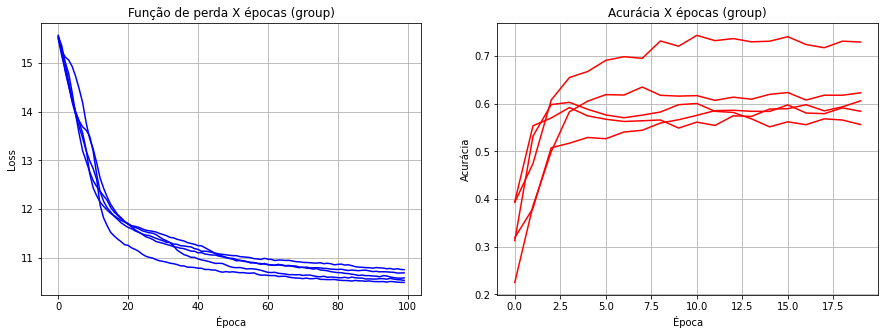

```
Resultados para a configuração distance - Acurácia: 0.43 - Desvio: 0.08
```

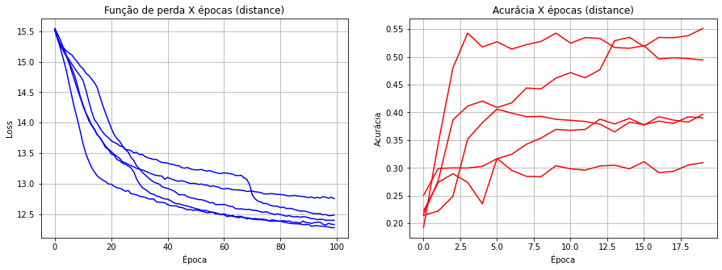

```python
for strategy in partition_strategies:
    num_k = len(results[strategy])
    fold_accuracy = []
    for i in range(num_k):
        fold_accuracy.append(results[strategy][i]['validation_acc'][-1])
    fold_accuracy = np.array(fold_accuracy)
    print("Resultados para a configuração {} - Acurácia: {:.2f} - Desvio: {:.2f}".format(strategy, np.mean(fold_accuracy), np.std(fold_accuracy)))
    fig, (ax1, ax2) = plt.subplots(1, 2, figsize=(15,5))
    for i in range(num_k):
        values = results[strategy][i]['train_loss']
        ax1.plot(range(len(values)), values, 'b')
        ax1.set_title('Função de perda X épocas ({})'.format(strategy))
        ax1.set_xlabel('Época')
        ax1.set_ylabel('Loss')
    ax1.grid()
    for i in range(num_k):
        values = results[strategy][i]['validation_acc']
        ax2.plot(range(len(values)), values, 'r')
        ax2.set_title('Acurácia X épocas ({})'.format(strategy))
        ax2.set_xlabel('Época')
        ax2.set_ylabel('Acurácia')
    ax2.grid()
    plt.show()
```

## Seleção do modelo

Como se pode perceber no gráfico acima, a estratégia de partição por grupo de membros apresentou melhores resultados, tanto em termo de desempenho como em termo de estabilidade (desvio padrão menor).

Os modelos treinados com a estratégia de grupo serão usados para as análises finais.

```python
device = torch.device('cuda')
selected_strategy = 'group'
selected_model = results[selected_strategy][1]['model']
selected_model.eval()
A = results[selected_strategy][1]['adjacency_matrix']
validation_dataset = results[selected_strategy][1]['validation_dataset']
```

```python
label_colors = {
    0: matplotlib.colors.to_rgb('#c62bc6'),
    1: matplotlib.colors.to_rgb('#49bcad'),
    2: matplotlib.colors.to_rgb('#e1ff00'),
    3: matplotlib.colors.to_rgb('#00bbff'),
    4: matplotlib.colors.to_rgb('#ffd800'),
    5: matplotlib.colors.to_rgb('#00ff11'),
    6: matplotlib.colors.to_rgb('#001dff'),
    7: matplotlib.colors.to_rgb('#fff600'),
    8: matplotlib.colors.to_rgb('#d65968'),
}

def create_segmentation_picture(values, nodes_per_frame=16):
    flatten_values = values.flatten()
    picture = np.array([ label_colors[i] for i in flatten_values])
    picture = picture.reshape((-1,nodes_per_frame, 3))
    picture = np.transpose(picture, (1,0,2))
    return picture

def define_label_by_frame(values, nodes_per_frame=16):
    flatten_values = values.flatten()
    frame_wise_mode = stats.mode(flatten_values.reshape((-1, nodes_per_frame)), axis=1)
    frame_pred = frame_wise_mode[0].flatten()
    frame_pred = np.array([ [ i for j in range(16)] for i in frame_pred ])
    return frame_pred

def print_legend():
    fig=plt.figure(figsize=(20, 4))
    for i in l.keys():
        fig.add_subplot(1, 7, i+1)
        plt.imshow(create_segmentation_picture(np.ones((16,16)) * i))
        plt.axis('off')
        plt.title(l[i])
    plt.show()

num_k = len(results[strategy])
all_data = []
all_preds = []
all_labels = []
for i in range(num_k):
    selected_strategy = 'group'
    selected_model = results[selected_strategy][i]['model']
    selected_model.eval()
    A = results[selected_strategy][i]['adjacency_matrix']
    validation_dataset = results[selected_strategy][i]['validation_dataset']

    validation_dataloader = DataLoader(validation_dataset, batch_size=batch_size, shuffle=True)

    for samples in validation_dataloader:
        data = samples['frames'].to(device, dtype=torch.float)
        labels = samples['labels'].to(device, dtype=torch.long)
        preds = selected_model(data, A)
        preds = torch.argmax(preds, dim=1)

    data = data.detach().cpu().numpy()
    preds = preds.detach().cpu().numpy()
    labels = labels.detach().cpu().numpy()

    all_data.append(data)
    all_preds.append(preds)
    all_labels.append(labels)

all_data = np.array(all_data).reshape(-1, 3, 212, 16)
all_preds = np.array(all_preds).reshape(-1, 212, 16)
all_labels = np.array(all_labels).reshape(-1, 212, 16)
```

## Exibição do resultado para algumas amostras

Abaixo seleciono três amostras e apresento o resultado da segmentação. Cada resultado contem três figuras.

1. Valores de referência (groud truth)
2. Classificação atribuída a cada vértice
3. Classificação final de cada frame

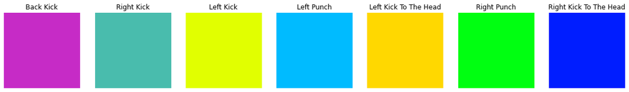

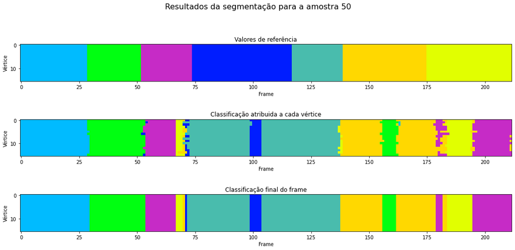

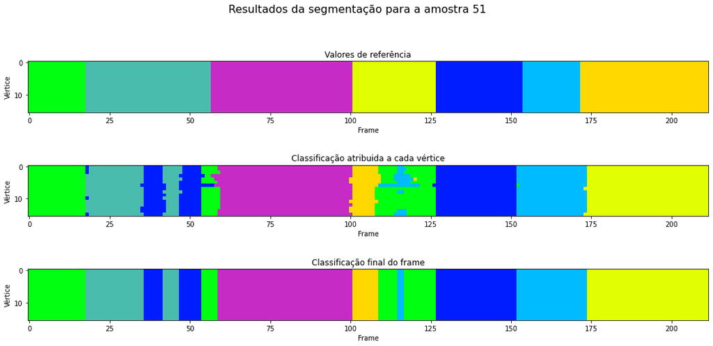

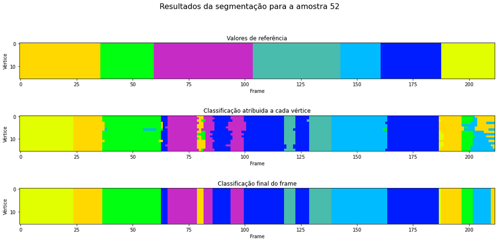

```python
print_legend()

for i in range(3):
    sample = all_data[sample_idx+i]
    pred = all_preds[sample_idx+i]
    label = all_labels[sample_idx+i]
    labels_picture = create_segmentation_picture(label)
    preds_by_node_picture = create_segmentation_picture(pred)
    preds_by_frame_picture = create_segmentation_picture(define_label_by_frame(pred))

    fig=plt.figure(figsize=(18, 8))
    fig.suptitle('Resultados da segmentação para a amostra {}'.format(sample_idx+i), fontsize=16)
    ax = fig.add_subplot(3, 1, 1)
    ax.set_title('Valores de referência')
    ax.set_xlabel('Frame')
    ax.set_ylabel('Vértice')
    plt.imshow(labels_picture)

    ax = fig.add_subplot(3, 1, 2)
    ax.set_title('Classificação atribuida a cada vértice')
    ax.set_xlabel('Frame')
    ax.set_ylabel('Vértice')
    plt.imshow(preds_by_node_picture)

    ax = fig.add_subplot(3, 1, 3)
    ax.set_title('Classificação final do frame')
    ax.set_xlabel('Frame')
    ax.set_ylabel('Vértice')
    plt.imshow(preds_by_frame_picture)

    plt.show()
```

## Matrix de confusão

Uma importante análise que pode ser feita neste problema é a análise da matriz de confusão. Através dela podemos verificar quais erros ocorrem com mais frequência, possívelmente mudando a arquitetura da rede ou acrescentando alguma informação (através de engenharia de dados) para tornar o trabalho da rede mais acertivo.

Analisando a matriz abaixo podemos ver que a rede consegue em geral diferenciar bem os movimentos dos atletas, porém confundindo os chutes diretos com os chutes na cabeça. De de fato são estas as classes mais difíceis de separar, dado que a perna (o membro mas importante no movimento) é a mesma, tendo o movimento uma dinâmica ligeiramente diferente e a altura final da perna sendo um pouco acima no caso do chute na cabeça.

Seguramente uma evolução deste trabalho focaria em encontrar formas de diferenciar estes movimentos.

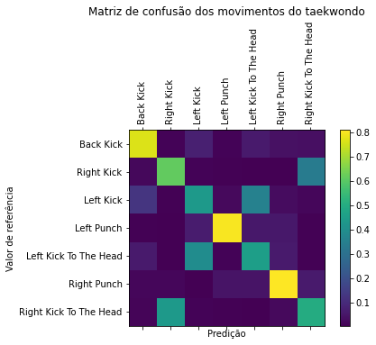

```python
cm = confusion_matrix(all_labels.flatten(), all_preds.flatten(), normalize='true')
fig = plt.figure()
ax = fig.add_subplot(111)
cax = ax.matshow(cm)
plt.title('Matriz de confusão dos movimentos do taekwondo')
fig.colorbar(cax)
ax.set_xticklabels(['']+ list(l.values()), rotation=90)
ax.set_yticklabels(['']+ list(l.values()))
plt.xlabel('Predição')
plt.ylabel('Valor de referência')
plt.show()
```

# Conclusão

A arquitetura se mostrou apropriada para o problema proposto, mas o tamanho pequeno do dataset se mostrou um grande desafio o que impediu o crescimento da rede mesmo com o data augmentation.

No caso deste problema a partição por grupos se mostrou mais apropriada que a partição por distância descrita no trabalho de Yan et al (2018). Um aspecto fundamental neste problema é a necessidade de separar os membros esquerdos e direitos, necessidade que não havia no trabalho original sendo esse, talvez, um dos motivos do melhor desempenho da partição por grupos.